# A Tutorial: Mixed-Data Cardiometabolic Phenotyping with HeterogeneousMixturesVI

A worked example on NHANES risk-factor data — draft companion tutorial, to be published once the manuscript is posted to arXiv

Authors

Affiliations

Wilson Toussile

ENSPY

Simeon Fotso

ENS

Patrice Takam Soh

University of Yaounde 1

Published

June 1, 2026

> **Status note (remove before publishing).** This is a draft tutorial, written to accompany the paper *Local Feature Relevance and Cluster Order Selection in Model-Based Clustering for Mixed Data via Variational Inference*. It is not part of the manuscript itself and is held back from publication until the paper is posted to arXiv.

## 1 What This Tutorial Covers

The package `HeterogeneousMixturesVI` fits Bayesian mixture models to mixed continuous/count/categorical data via coordinate-ascent variational inference (CAVI), automatically selecting the number of clusters and identifying which features actually drive cluster structure — without you having to choose $K$ in advance or decide by hand which variables to control for. This tutorial walks through a complete real-data application end to end:

1. Building a real, public dataset from raw source files (NHANES cardiometabolic risk factors).
2. Fitting the **Shared Feature Relevance Model (SFRM)**, where each feature’s relevance is shared across all clusters.
3. Fitting the **Local Feature Relevance Model (LFRM)**, where relevance can differ cluster by cluster.
4. Reading the diagnostics the package gives you — Posterior Inclusion Probabilities (PIP) and Expected Information Gain (EIG) — to decide which features matter and why.
5. Relating the result to an independently published analysis of similar data, to calibrate what “a good result” looks like here.

The full derivations behind SFRM, LFRM, and the CAVI updates are in the accompanying paper and its supplementary material; this tutorial assumes you already have the package installed and focuses on *using* it.

## 2 The Dataset: NHANES Cardiometabolic Risk Factors

The National Health and Nutrition Examination Survey (NHANES) is an ongoing, public health survey run by the U.S. CDC, combining interviews, physical examinations, and laboratory tests. It is a natural testbed for mixed-data clustering: it mixes continuous physiological measurements, categorical lifestyle variables, and (depending on the extract) count data, all on a genuinely large, heterogeneous population.

We build an extract of 11 cardiometabolic risk factors plus smoking status, for adults aged 40-59, from the **2017-2018 NHANES cycle** (National Center for Health Statistics 2020) — the most recent complete cycle unaffected by COVID-era protocol changes. This variable set mirrors Wang et al. (2026), an independently published CAVI-based mixture model paper that analyzes a similar NHANES risk-factor extract; we will come back to that comparison in Section 4.

### 2.1 Step 1: Download the Raw Files

NHANES distributes each component as a separate SAS transport (`.xpt`) file. For the variables we need, that means eight files, all on the same naming pattern (`<COMPONENT>_J` for the 2017-2018 cycle):

```bash
for f in DEMO_J BMX_J BPX_J HDL_J TCHOL_J GHB_J BIOPRO_J SMQ_J; do
  curl -sL -o "${f}.xpt" "https://wwwn.cdc.gov/Nchs/Data/Nhanes/Public/2017/DataFiles/${f}.xpt"
done
```

| Component | File | What it gives us |
| --- | --- | --- |
| Demographics | `DEMO_J` | age, sex |
| Body Measures | `BMX_J` | BMI, height, waist circumference |
| Blood Pressure | `BPX_J` | systolic/diastolic readings, pulse |
| Cholesterol — HDL | `HDL_J` | HDL cholesterol |
| Cholesterol — Total | `TCHOL_J` | total cholesterol (combined with HDL to get non-HDL) |
| Glycohemoglobin | `GHB_J` | HbA1c |
| Standard Biochemistry | `BIOPRO_J` | serum creatinine (for eGFR) |
| Smoking | `SMQ_J` | smoking history and current status |

### 2.2 Step 2: Harmonize the Variables

Each `.xpt` file is keyed by `SEQN` (respondent ID), so the build step is a sequence of inner joins followed by some derived-variable construction. The full script is `experiments/scripts/build_nhanes_dataset.py`; the key pieces are:

```python
df = demo.merge(bmx, on="SEQN").merge(bpx, on="SEQN") \
          .merge(hdl, on="SEQN").merge(tchol, on="SEQN") \
          .merge(ghb, on="SEQN").merge(biopro, on="SEQN").merge(smq, on="SEQN")

df = df[(df.RIDAGEYR >= 40) & (df.RIDAGEYR <= 59)]   # age filter
df["sex"] = df.RIAGENDR.map({1: "male", 2: "female"})

df["SBP"] = df[["BPXSY1", "BPXSY2", "BPXSY3", "BPXSY4"]].mean(axis=1, skipna=True)
df["WHtR"] = df.BMXWAIST / df.BMXHT
df["non_HDL"] = df.LBXTC - df.LBDHDD
df["eGFR"] = egfr_ckdepi_2021(df.LBXSCR, df.RIDAGEYR, df.sex)   # CKD-EPI 2021, sex-specific
df["smoking"] = df.apply(smoking_status, axis=1)                # never / former / current
```

`eGFR`, the estimated glomerular filtration rate, is computed via the CKD-EPI 2021 race-free equation, which uses different coefficients for males and females — get this wrong and you introduce a spurious sex-correlated bias into a variable you’ll later be asking the model to evaluate for sex-related relevance, so it is worth getting right at the source rather than downstream.

The harmonized CSV is saved to `experiments/data/nhanes_2017_2018_40_59.csv`.

## 3 Fitting the Model

`HeterogeneousMixturesVI` represents a dataset as a vector of per-feature columns — `Float64` vectors for continuous (Gaussian) features, vectors of one-hot vectors for categorical (Multinomial) features — and standardizes continuous features before fitting:

```julia
using HeterogeneousMixturesVI, CSV, DataFrames, Statistics, Random

df = CSV.read("nhanes_2017_2018_40_59.csv", DataFrame)

dataset = Vector{Any}(undef, 12)
dataset[1:10] = [Float64.(df[!, c]) for c in
                 [:bmi, :height, :WHtR, :SBP, :DBP, :pulse, :hdl, :non_HDL, :hba1c, :eGFR]]
dataset[11] = [onehot(x, ["male", "female"]) for x in df.sex]
dataset[12] = [onehot(x, ["never", "former", "current"]) for x in df.smoking]

for j in 1:10
    dataset[j] = (dataset[j] .- mean(dataset[j])) ./ std(dataset[j])
end
```

With the data in this form, fitting either model setting is a single call. We start the CAVI algorithm with $K_{\text{fit}}=10$ components — deliberately more than we expect to need — and let the sparse Dirichlet prior plus post-hoc pruning determine the right number automatically:

```julia
Random.seed!(42)
res = fit_cavi(dataset, 10;
               model_setting = GlobalRelevance(),  # SFRM; use LocalRelevance() for LFRM
               alpha_0 = 0.01,
               max_iter = 2000,
               tol = 1e-5,
               prune = true)
```

`res.w` is the $n \times \widehat{K}$ matrix of soft cluster assignments, `res.pip` the per-feature Posterior Inclusion Probabilities, and `res.margins` the fitted margin objects used by `compute_eig` and `plot_profiles` for further diagnostics. The full script, including plotting, is `experiments/scripts/nhanes_data_analysis.jl`.

### 3.1 SFRM: Shared Relevance

Under the **Shared Feature Relevance Model**, each feature has a single relevance probability shared by every cluster — a feature is either generally informative or it isn’t. Fitting it here, CAVI converges in 1680/2000 iterations and prunes the 10 starting components down to $\widehat{K}=8$ active clusters, with sizes 336, 287, 258, 206, 110, 94, 90, 50.

| Feature | PIP | EIG |
| --- | --- | --- |
| `bmi` | 0.999 | 0.844 |
| `height` | 0.996 | 0.214 |
| `WHtR` | 0.998 | 0.823 |
| `SBP` | 0.712 | 0.215 |
| `DBP` | 0.964 | 0.090 |
| `pulse` | 0.735 | 0.090 |
| `hdl` | 0.869 | 0.291 |
| `non_HDL` | 0.710 | 0.064 |
| `hba1c` | 0.986 | 0.786 |
| `eGFR` | 0.393 | 0.198 |
| `sex` | 0.999 | 0.331 |
| `smoking` | 0.812 | 0.035 |

Two diagnostics, two different questions:

- **PIP** answers “is this feature included in the cluster-specific (active) density at all, as opposed to following the shared background density?” High PIP means the model is confident the feature should be modeled per cluster rather than pooled.
- **EIG** answers “how much does that inclusion actually separate the clusters?” A feature can have high PIP (the model confidently includes it) yet low EIG (its cluster-specific values barely differ from the population average) — `smoking` here is a clean example: PIP $=0.812$ but EIG only $0.035$.

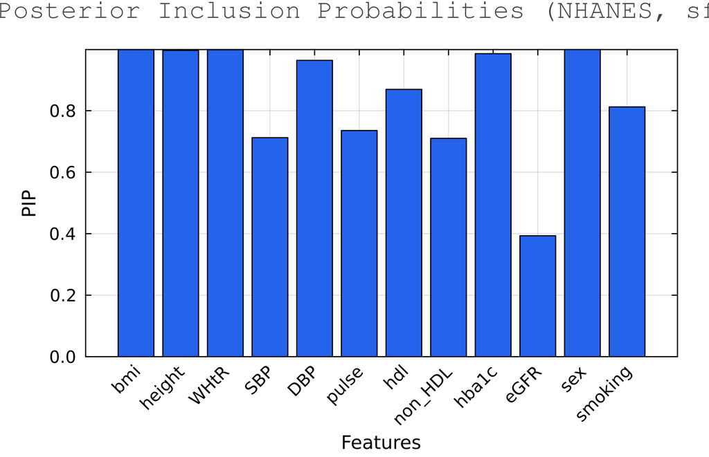

SFRM: Posterior Inclusion Probabilities

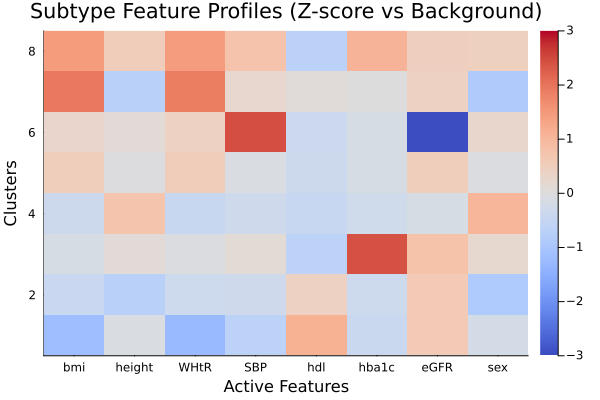

SFRM: Subtype feature profiles (z-score vs. background)

`plot_profiles` shows, for each active cluster and each EIG-selected feature, the cluster’s expected value as a z-score against the shared background distribution. Reading across the rows recovers recognizable phenotypes: a markedly low-eGFR cluster (impaired kidney function), a high-HbA1c cluster (hyperglycemia), and a couple of BMI/WHtR-elevated clusters of differing severity — broadly the same kind of phenotype categories reported in Wang et al. (2026) and Lhoste et al. (2024), obtained here with no manual phenotype-naming step.

### 3.3 LFRM: Local Relevance

The **Local Feature Relevance Model** relaxes the shared-relevance assumption: each feature gets its own relevance probability *per cluster*, so a feature can be discriminative for distinguishing some clusters but irrelevant for others. Swap `GlobalRelevance()` for `LocalRelevance()` and refit:

```julia
Random.seed!(42)
res = fit_cavi(dataset, 10; model_setting = LocalRelevance(), alpha_0 = 0.01,
               max_iter = 2000, tol = 1e-5, prune = true)
```

CAVI converges in 1184/2000 iterations, pruning to $\widehat{K}=9$ active clusters (sizes 516, 322, 200, 129, 63, 56, 53, 52, 40).

| Feature | PIP | EIG |
| --- | --- | --- |
| `bmi` | 0.994 | 0.971 |
| `height` | 0.714 | 0.064 |
| `WHtR` | 0.993 | 0.914 |
| `SBP` | 0.674 | 0.246 |
| `DBP` | 0.619 | 0.110 |
| `pulse` | 0.566 | 0.150 |
| `hdl` | 0.697 | 0.384 |
| `non_HDL` | 0.691 | 0.126 |
| `hba1c` | 0.947 | 0.825 |
| `eGFR` | 0.339 | 0.340 |
| `sex` | 0.818 | 0.060 |
| `smoking` | 0.399 | 0.032 |

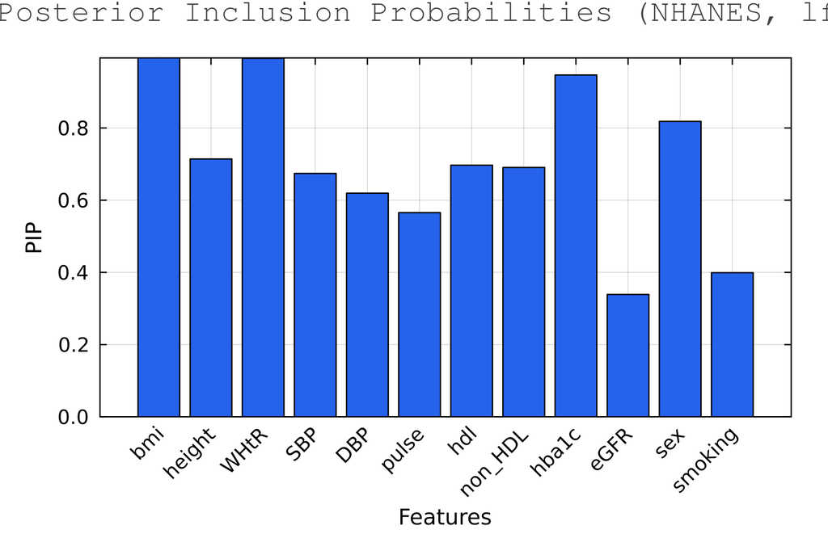

LFRM: Posterior Inclusion Probabilities

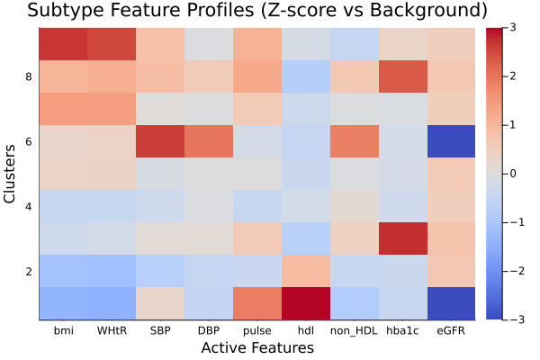

LFRM: Subtype feature profiles (z-score vs. background)

The result worth pausing on: `sex`’s EIG **collapses** from $0.331$ under SFRM to $0.060$ under LFRM, and `height`’s drops similarly ($0.214 \to 0.064$). Nothing about the underlying data changed between the two fits — only the model’s flexibility did. Once relevance is allowed to vary by cluster, the per-cluster profiles of other, correlated continuous features (`height`, `hdl`, body composition) already absorb most of the sex-correlated variation directly, so an explicit, globally-shared `sex` effect is no longer needed to explain the same structure. This is the practical reason LFRM exists: **a feature that looks like a strong, uniform driver under a shared-relevance assumption can turn out to be a redistributable, cluster-specific effect once you allow for it** — and you only find this out by fitting both and comparing, which is why we recommend doing so as a matter of routine rather than committing to one setting in advance.

One more useful comparison: mean assignment confidence (the average of each individual’s largest posterior cluster-membership weight) is $0.915$ for SFRM and $0.927$ for LFRM here — the extra flexibility did not come at the cost of fuzzier clusters in this case, despite fitting an additional cluster.

## 4 Relating This to Published Work

Wang et al. (2026) fit a CAVI-based mixture model to a similar NHANES risk-factor extract (pooled across the 1988-2018 cycles, males aged 40-59 only). Their likelihood

$$p(x_i, c_i \mid \mu, \Lambda, \psi, \pi) = \sum_{k=1}^K \pi_k \, \mathcal{N}(x_i \mid \mu_k, \Lambda_k^{-1}) \prod_{j=1}^p \psi_{k,j,c_{ij}}$$

treats every feature as fully informative in every cluster: there is no background/active switch and no relevance mechanism of any kind. Concretely, this means their pipeline:

- Fixes $K=10$ a priori, carried over from a separate K-means analysis of a different paper (Lhoste et al. 2024) on the continuous variables alone, rather than letting the model select $K$. (Their own posterior mixture weights show two of the ten components carrying negligible mass — $\pi_1=0.0008$, $\pi_2=0.0006$ — i.e. the fit is implicitly telling them $K$ was over-specified, but nothing in a relevance-free pipeline acts on that automatically.)
- Cannot say which variables actually drive the clustering — every one of their variables contributes a mean and covariance term to every cluster by construction, so a variable like `height`, here flagged at PIP $\approx 0$ in the manuscript’s UCI Heart Disease application and at moderate-to-low EIG even when sex-confounded here, would be indistinguishable from a strongly discriminative variable in their output.
- Validates results entirely qualitatively, by matching each fitted cluster’s profile, by eye, to a named phenotype from a separately published K-means analysis. No quantitative diagnostic equivalent to PIP or EIG is available.

Despite the different cycles and sample sizes, both analyses recover broadly the same phenotype categories — a hyperglycemia-dominant cluster, an obesity/elevated-BMI cluster, a near-median “typical” cluster, clusters distinguished by lipid or renal markers — which is a reasonable face-validity check on its own. What the comparison mainly illustrates, though, is what an explicit relevance mechanism buys you in practice: automatic order selection instead of a separate manual clustering step, a direct quantitative answer to “does this variable matter” instead of an assumption, and — via SFRM vs. LFRM — the ability to detect when a variable’s apparent importance is actually a redistributable, cluster-specific effect rather than a uniform one.

## 5 Takeaways

- Fit **both** SFRM and LFRM as a matter of course; the comparison itself (which features change EIG, and how much) is informative, as the `sex`/`height` example here shows.
- Read **PIP** as “should this feature be modeled per cluster at all” and **EIG** as “how much does that inclusion actually separate clusters” — they answer different questions and can disagree (`smoking` above).
- A relevance mechanism gives you a real alternative to manually excluding a suspected confounding variable: model it explicitly and let the diagnostics tell you whether the concern was warranted, and whether it is global (SFRM) or local to specific clusters (LFRM).
- The sparse-Dirichlet-prior-plus-pruning order-selection mechanism removes the need for a separate, external clustering step (e.g. K-means) just to pick $K$ before fitting your actual model.

For the full derivation of SFRM, LFRM, the CAVI updates, and the post-hoc pruning/EIG-filtering pipeline used throughout this tutorial, see the accompanying paper and its supplementary material.

## 6 Reproducibility

| Artifact | Path |
| --- | --- |
| Raw-data harmonization script | `experiments/scripts/build_nhanes_dataset.py` |
| Harmonized dataset | `experiments/data/nhanes_2017_2018_40_59.csv` |
| Model-fitting script | `experiments/scripts/nhanes_data_analysis.jl` |
| Figures | `experiments/figures/nhanes_{pips,profiles,assignments}_{sfrm,lfrm}.png` |

## References

Lhoste, Victor P. F., Bin Zhou, Aishwarya Mishra, et al. 2024. “Cardiometabolic and Renal Phenotypes and Transitions in the United States Population.” *Nature Cardiovascular Research* 3 (1): 46–59. https://doi.org/10.1038/s44161-023-00391-y.

National Center for Health Statistics. 2020. *National Health and Nutrition Examination Survey, 2017-2018 Data Documentation, Codebook, and Frequencies*. Centers for Disease Control and Prevention. https://wwwn.cdc.gov/nchs/nhanes/continuousnhanes/default.aspx?BeginYear=2017.

Wang, Junyang, James Bennett, Victor Lhoste, and Sarah Filippi. 2026. “Bayesian Variational Inference for Mixed Data Mixture Models.” *arXiv Preprint*. https://arxiv.org/abs/2507.16545.